# IGARSS Training: Python Notebooks

Task-A: Cloud-free Mosaics and K-means Clustering

### Import the Datacube Configuration

```python
# Supress Warning
import warnings
warnings.filterwarnings('ignore')

import datacube
dc = datacube.Datacube(app = 'my_app', config = '/home/localuser/.datacube.conf')
```

### Browse the available Data Cubes

```python
list_of_products = dc.list_products()
netCDF_products = list_of_products[list_of_products['format'] == 'NetCDF']
# netCDF_products
dc.list_products()
```

| id | name | description | time | instrument | lat | platform | product_type | lon | format | crs | resolution | tile_size | spatial_dimensions |
| --- | --- | --- | --- | --- | --- | --- | --- | --- | --- | --- | --- | --- | --- |
| 8 | ls7_collections_sr_scene | Landsat 7 USGS Collection 1 Higher Level SR sc... | None | ETM | None | LANDSAT_7 | LEDAPS | None | GeoTiff | NaN | NaN | NaN | NaN |
| 87 | ls7_ledaps_caqueta | Landsat 7 USGS Collection 1 Higher Level SR sc... | None | ETM1 | None | LANDSAT_7 | LEDAPS | None | NetCDF | EPSG:4326 | [-0.000269494585236, 0.000269494585236] | [0.538989170472, 0.538989170472] | (latitude, longitude) |
| 22 | ls7_ledaps_ghana | Landsat 7 USGS Collection 1 Higher Level SR sc... | None | ETM | None | LANDSAT_7 | LEDAPS | None | NetCDF | EPSG:4326 | [-0.000269494585236, 0.000269494585236] | [0.943231048326, 0.943231048326] | (latitude, longitude) |
| 31 | ls7_ledaps_vietnam | Landsat 7 USGS Collection 1 Higher Level SR sc... | None | ETM | None | LANDSAT_7 | LEDAPS | None | NetCDF | EPSG:4326 | [-0.000269494585236, 0.000269494585236] | [0.943231048326, 0.943231048326] | (latitude, longitude) |

### Pick a product

> Use the platform and product names from the previous block to select a Data Cube.

```python
import utils.data_cube_utilities.data_access_api as dc_api
api = dc_api.DataAccessApi(config = '/home/localuser/.datacube.conf')

# Change the data platform and data cube here

platform = "LANDSAT_7"

product = "ls7_ledaps_vietnam"
# product = "ls7_ledaps_bangladesh"

# Get Coordinates
coordinates = api.get_full_dataset_extent(platform = platform, product = product)
```

#### Display Latitude-Longitude and Time Bounds of the Data Cube

```python
latitude_extents = (min(coordinates['latitude'].values),max(coordinates['latitude'].values))
print( latitude_extents )
```

```
(9.187474652573094, 13.95375588705699)
```

```python
longitude_extents = (min(coordinates['longitude'].values),max(coordinates['longitude'].values))
print( longitude_extents )
```

```
(102.40430421277932, 108.93092407802477)
```

```python
time_extents = (min(coordinates['time'].values),max(coordinates['time'].values))
print( time_extents )
```

```
(numpy.datetime64('2008-01-11T03:16:09.000000000'), numpy.datetime64('2016-12-29T03:10:00.000000000'))
```

# Visualize Data Cube Region

```python
## The code below renders a map that can be used to orient yourself with the region.
from utils.data_cube_utilities.dc_display_map import display_map
display_map(latitude = latitude_extents, longitude = longitude_extents)
```

[interactive chart not shown]

### Pick a smaller analysis region and display that region

> Try to keep your region to less than 0.2-deg x 0.2-deg for rapid processing Pick the time extents for your mosaic product (keep to 1 year or less)

```python
## Vietnam - Central Lam Dong Province ##
longitude_extents = (107.80, 108.00)
latitude_extents  = (11.70, 11.90)

time_extents = ('2012-01-01', '2013-01-01')
print ( time_extents )
```

```
('2012-01-01', '2013-01-01')
```

```python
display_map(latitude = latitude_extents, longitude = longitude_extents)
```

[interactive chart not shown]

## Load the dataset and the required spectral bands or other parameters

After loading, you will view the Xarray dataset. Notice the dimensions represent the number of pixels in your latitude and longitude dimension as well as the number of time slices (time) in your time series.

```python
landsat_dataset = dc.load(latitude = latitude_extents,
                          longitude = longitude_extents,
                          platform = platform,
                          time = time_extents,
                          product = product,
                          measurements = ['red', 'green', 'blue', 'nir', 'swir1', 'swir2', 'pixel_qa'])
```

```python
landsat_dataset
#view the dimensions and sample content from the cube
```

```
<xarray.Dataset>
Dimensions:    (latitude: 743, longitude: 743, time: 11)
Coordinates:
  * time       (time) datetime64[ns] 2012-01-01T03:01:39 2012-01-17T03:01:41 ...
  * latitude   (latitude) float64 11.9 11.9 11.9 11.9 11.9 11.9 11.9 11.9 ...
  * longitude  (longitude) float64 107.8 107.8 107.8 107.8 107.8 107.8 107.8 ...
Data variables:
    red        (time, latitude, longitude) int16 20000 20000 20000 20000 ...
    green      (time, latitude, longitude) int16 20000 20000 20000 20000 ...
    blue       (time, latitude, longitude) int16 20000 20000 20000 20000 ...
    nir        (time, latitude, longitude) int16 6977 6932 6932 6889 6716 ...
    swir1      (time, latitude, longitude) int16 4828 4828 4855 4908 4828 ...
    swir2      (time, latitude, longitude) int16 3121 3263 3349 3378 3320 ...
    pixel_qa   (time, latitude, longitude) int32 224 224 224 224 224 224 224 ...
Attributes:
    crs:      EPSG:4326
```

# Display Example Images

#### Single band visualization

```python
acquisition_number = 9
# Select a single acquistion to view
# The acquisitions are numbered, starting at 0 and ending at time-1 (from above)
```

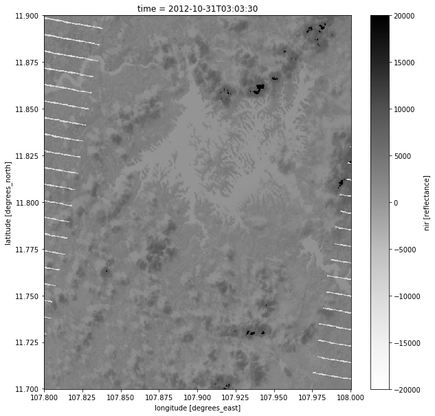

```python
%matplotlib inline
#landsat_dataset.red.isel(time = acquisition_number).plot(cmap = "Greys")
#landsat_dataset.green.isel(time = acquisition_number).plot(cmap = "Greys")
#landsat_dataset.blue.isel(time = acquisition_number).plot(cmap = "Greys")
landsat_dataset.nir.isel(time = acquisition_number).plot(cmap = "Greys", figsize=(10,10))
#landsat_dataset.swir1.isel(time = acquisition_number).plot(cmap = "Greys")
#landsat_dataset.swir2.isel(time = acquisition_number).plot(cmap = "Greys")
```

#### Define Cloud Masking Function

> Removes clouds and cloud shadows based on the Landsat pixel QA information This is only for reference ... nothing to modify here

```python
import numpy as np

def generate_cloud_mask(dataset, include_shadows = False):
    #Create boolean Masks for clear and water pixels
    clear_pixels = dataset.pixel_qa.values == 2  + 64
    water_pixels = dataset.pixel_qa.values == 4  + 64
    shadow_pixels= dataset.pixel_qa.values == 8 + 64

    a_clean_mask = np.logical_or(clear_pixels, water_pixels)

    if include_shadows:
        a_clean_mask = np.logical_or(a_clean_mask, shadow_pixels)

    return np.invert(a_clean_mask)

def remove_clouds(dataset, include_shadows = False):
    #Create boolean Masks for clear and water pixels
    clear_pixels = dataset.pixel_qa.values == 2  + 64
    water_pixels = dataset.pixel_qa.values == 4  + 64
    shadow_pixels= dataset.pixel_qa.values == 8 + 64

    a_clean_mask = np.logical_or(clear_pixels, water_pixels)

    if include_shadows:
        a_clean_mask = np.logical_or(a_clean_mask, shadow_pixels)

    return dataset.where(a_clean_mask)
```

#### Mask clouds from your selected acquisition and visualize the scene and mask

> Now we will look at two RGB images where the second image includes the cloud, cloud shadow and no data mask in RED. Also, the scene is the same as the acquistion selected above.

```python
cloud_mask = generate_cloud_mask(landsat_dataset)
cloudless = remove_clouds(landsat_dataset) #landsat_dataset.where(image_is_clean)
```

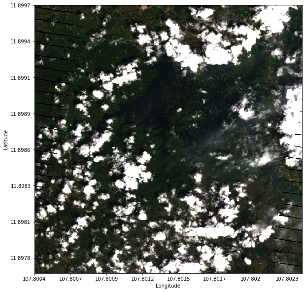

```python
from utils.data_cube_utilities.dc_rgb import rgb

rgb(landsat_dataset, at_index = acquisition_number, bands = ['red','green','blue'])
# You can change the bands for other false color images (e.g. swir2, nir, green)
```

```python
red = [255,0,0]
```

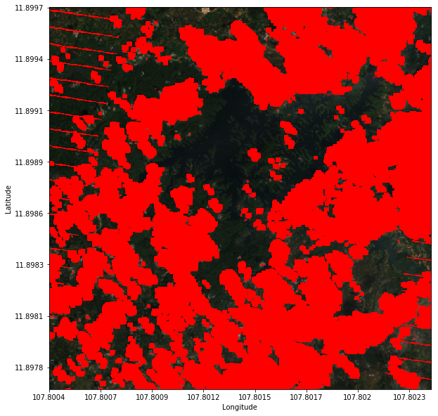

```python
rgb(landsat_dataset, at_index = acquisition_number, paint_on_mask = [(cloud_mask, red)])
```

# Cleaning up the clouds and creating a cloud-free mosaic

Remember that this process will filter clouds from the entire time series stack

> **Most Recent Pixel Mosaic**  
> Masks clouds from imagery and uses the most recent cloud-free pixels.

```python
from utils.data_cube_utilities.dc_mosaic import create_mosaic

def mrf_mosaic(dataset):
    # The mask here is based on pixel_qa products. It comes bundled in with most Landsat Products.
    cloud_free_boolean_mask = np.invert(generate_cloud_mask(dataset))
    return create_mosaic(dataset, clean_mask = cloud_free_boolean_mask)
```

```python
recent_composite = mrf_mosaic(landsat_dataset)
```

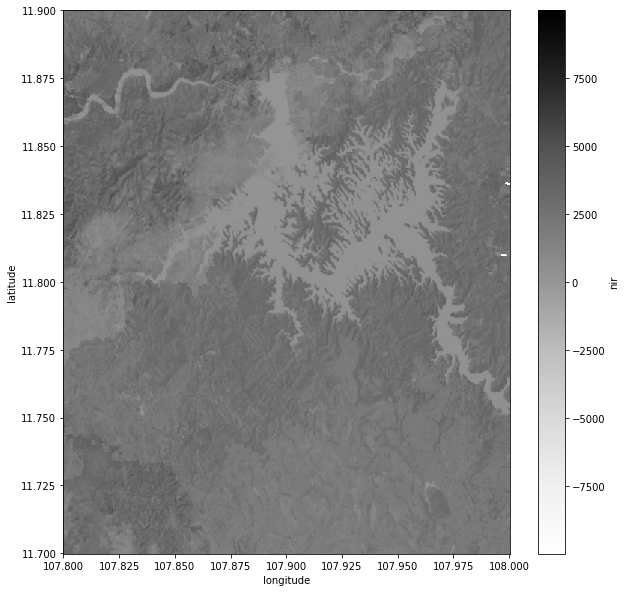

```python
recent_composite.nir.plot(cmap = "Greys", figsize=(10,10))
```

```python
rgb(recent_composite)
recent_composite.keys()
```

[output not shown]

```
KeysView(<xarray.Dataset>
Dimensions:    (latitude: 743, longitude: 743)
Coordinates:
  * latitude   (latitude) float64 11.9 11.9 11.9 11.9 11.9 11.9 11.9 11.9 ...
  * longitude  (longitude) float64 107.8 107.8 107.8 107.8 107.8 107.8 107.8 ...
Data variables:
    red        (latitude, longitude) int16 655 638 552 605 657 691 778 795 ...
    green      (latitude, longitude) int16 597 560 503 523 599 618 619 620 ...
    blue       (latitude, longitude) int16 428 376 325 361 362 397 451 435 ...
    nir        (latitude, longitude) int16 2055 1900 1900 2053 2284 2283 ...
    swir1      (latitude, longitude) int16 1804 1734 1455 1687 1756 1803 ...
    swir2      (latitude, longitude) int16 1265 1167 923 1020 996 1094 1337 ...
    pixel_qa   (latitude, longitude) int32 66 66 66 66 66 66 66 66 66 66 66 ...)
```

> **Median Mosaic**  
> Masks clouds from imagery using the median valued cloud-free pixels in the time series

```python
from utils.data_cube_utilities.dc_mosaic import create_median_mosaic

def median_mosaic(dataset):
    # The mask here is based on pixel_qa products. It comes bundled in with most Landsat Products.
    cloud_free_boolean_mask = np.invert(generate_cloud_mask(dataset))
    return create_median_mosaic(dataset, clean_mask = cloud_free_boolean_mask)
```

```python
median_composite = median_mosaic(landsat_dataset)
```

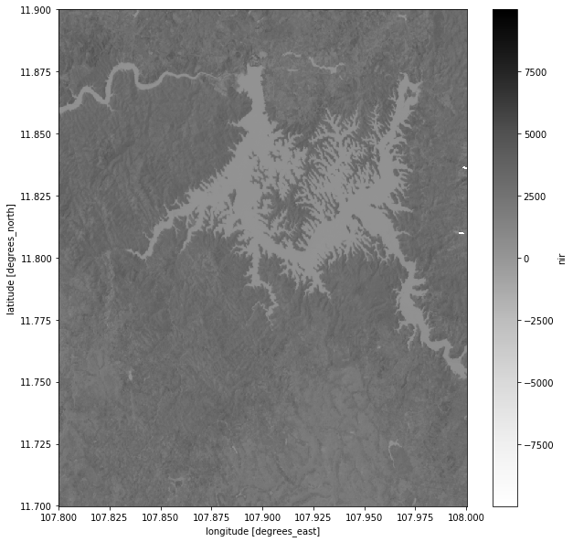

```python
median_composite.nir.plot(cmap = "Greys", figsize=(10,10))
```

```python
rgb(median_composite)
```

[output not shown]

## Select bands used for clustering

```python
cluster_bands = ['red', 'green', 'blue', 'swir1', 'nir']
```

# Perform K-Means clustering and view the output

```python
def figure_ratio(ds, fixed_width = 10):
    width = fixed_width
    height = len(ds.latitude) * (fixed_width / len(ds.longitude))
    return (width, height)
```

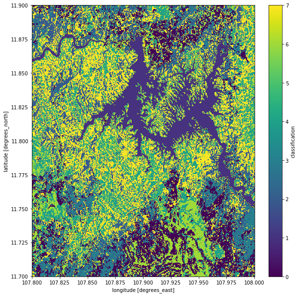

```python
from utils.data_cube_utilities.dc_clustering import kmeans_cluster_dataset

# change the number of clusters in the line below, as desired
# this example uses the "median composite" image from above
classification_x =  kmeans_cluster_dataset(median_composite, cluster_bands, n_clusters=8)
# plot the k-mean classification result
classification_x.classification.plot(figsize = figure_ratio(classification_x))
```